# Chapter8

# Should you include a constant in the model? Explain

Nu voi include o constanta in model, ci va fi realizata diferentierea de doua ori. Introducerea unei constante poate crea un trend.

# Write this model in terms of backshift operator

(1-B)^2Yt = (1 + thetaB + theta2B^2)*epsilont

# Fit the model using R and examine the residuals. Is the model satisfactory?

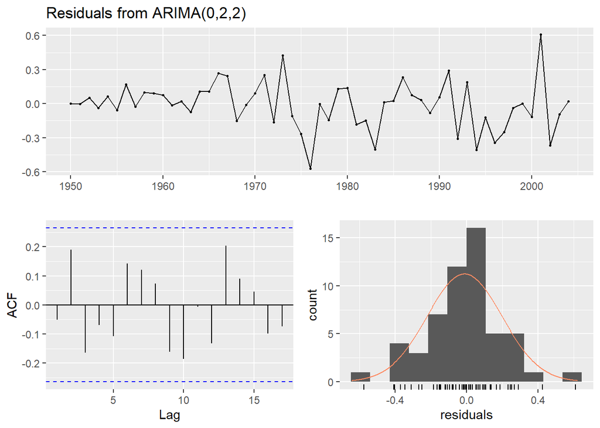

```
##
##  Ljung-Box test
##
## data:  Residuals from ARIMA(0,2,2)
## Q* = 11.764, df = 8, p-value = 0.1621
##
## Model df: 2.   Total lags used: 10
```

```r
ex.arima <- Arima(wmurders, order = c(0,2,2))
checkresiduals(ex.arima)
```

# Forecast three times ahead. Check your forecasts by hand to make sure that you know how they have been calculated.

```r
ex.arima <- forecast (ex.arima, h = 3)
```

Vom face o predictie cu o functie Arima

```r
ex.arima$mean
```

```
## Time Series:
## Start = 2005
## End = 2007
## Frequency = 1
## [1] 2.480525 2.374890 2.269256
```

```r
ex.arima$model
```

```
## Series: wmurders
## ARIMA(0,2,2)
##
## Coefficients:
##           ma1     ma2
##       -1.0181  0.1470
## s.e.   0.1220  0.1156
##
## sigma^2 estimated as 0.04702:  log likelihood=6.03
## AIC=-6.06   AICc=-5.57   BIC=-0.15
```

Formula va fi:

(1 - B)^2Yt = (1 - 1.0181B + 0.147B^2)epsilont Yt = 2Yt-1 - Yt-2 + epsilont - 1.0181epsliont-1 + 0.147epsilont-2

```r
len <- length(wmurders)
e <- ex.arima$residuals

f1 <- 2*wmurders[len] - wmurders[len - 1] - 1.0181*e[len] + 0.147*e[len - 1]
f2 <- 2*f1 - wmurders[len] + 0.147*e[len]
f3 <- 2*f2 - f1

c(f1,f2,f3)
```

```
## [1] 2.480523 2.374887 2.269252
```

# Create a plot of the series with the forecasts and precition intervals for the next three periods shown.

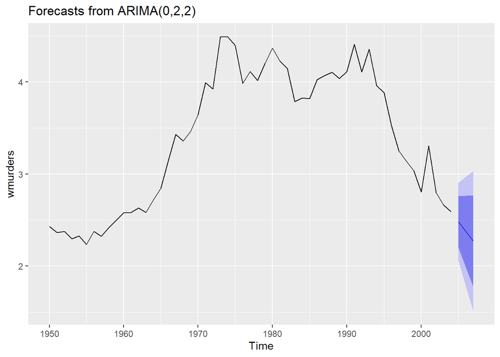

```r
autoplot(ex.arima)
```

# Does auto.arima() give the same model you have chosen? If not, which model do you think is better?

```r
ex.autoarima <- forecast( auto.arima(wmurders), h = 3)

accuracy(ex.arima)
```

```
##                      ME      RMSE       MAE        MPE     MAPE      MASE
## Training set -0.0113461 0.2088162 0.1525773 -0.2403396 4.331729 0.9382785
##                     ACF1
## Training set -0.05094066
```

```r
accuracy(ex.autoarima)
```

```
##                       ME      RMSE       MAE        MPE     MAPE      MASE
## Training set -0.01065956 0.2072523 0.1528734 -0.2149476 4.335214 0.9400996
##                    ACF1
## Training set 0.02176343
```

Valorile date de 0,2,2 sunt mai bune (luand in considerare rezultate date de accuracy)

## Exercitiul 8

Consider the total international visitors to Australia (in millions) for the period 1980-2015. (Data set austa.)

# Use auto.arima to find an appropriate ARIMA model. What model was selected. Check that the residuals look like white noise. Plot forecasts for the next 10 periods.

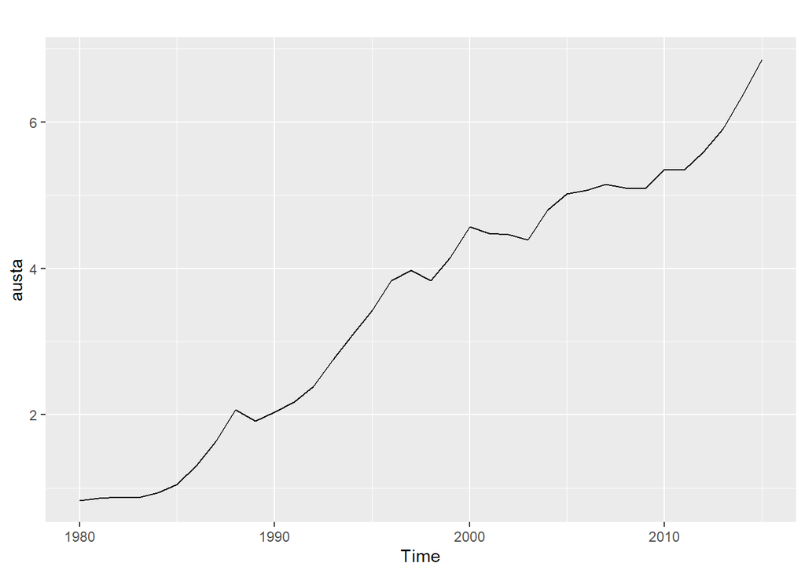

```r
autoplot(austa)
```

```r
austa.arima <- forecast(auto.arima(austa), h = 10)

austa.arima$model
```

```
## Series: austa
## ARIMA(0,1,1) with drift
##
## Coefficients:
##          ma1   drift
##       0.3006  0.1735
## s.e.  0.1647  0.0390
##
## sigma^2 estimated as 0.03376:  log likelihood=10.62
## AIC=-15.24   AICc=-14.46   BIC=-10.57
```

ARIMA(0,1,1) with drift

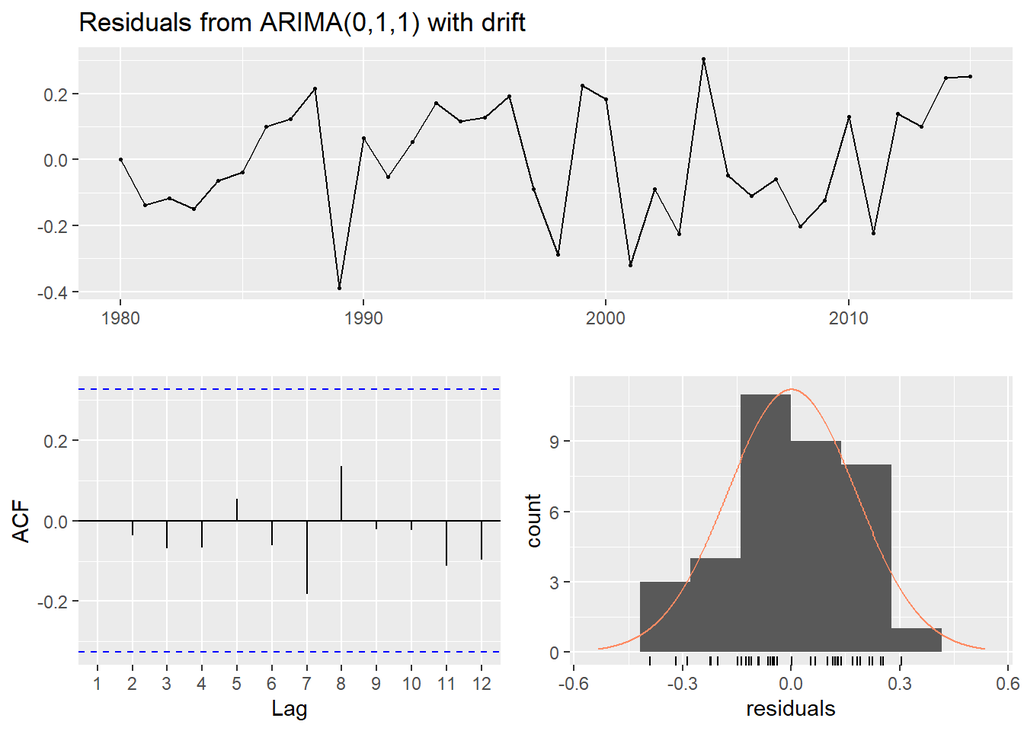

```
##
##  Ljung-Box test
##
## data:  Residuals from ARIMA(0,1,1) with drift
## Q* = 2.297, df = 5, p-value = 0.8067
##
## Model df: 2.   Total lags used: 7
```

```r
checkresiduals(austa.arima)
```

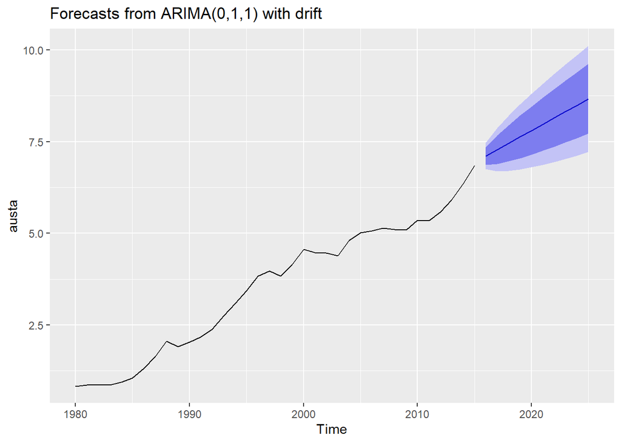

```r
autoplot(austa.arima)
```

# Plot forecasts from an ARIMA(0,1,1) model with no drift and compare these to part a. Remove the MA term and plot again.

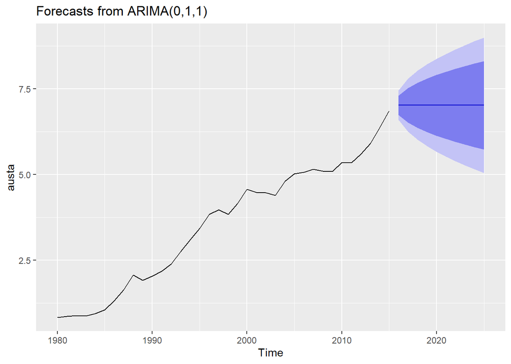

```r
austa.arima011 <- forecast(Arima(austa, order = c(0,1,1)), h = 10)
autoplot(austa.arima011)
```

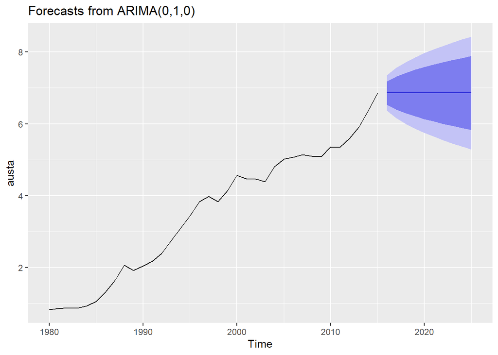

```r
austa.arima010 <- forecast(Arima(austa, order = c(0,1,0)), h = 10)
autoplot(austa.arima010)
```